# Plate Reader 19: YPD pH 4, 5.5, 7, 8.5 and without HEPES

Liz Hughes

26-09-21

#Plate reader assay.

Set up to test growth of WT, Gat201 Madhani deletion and Gat201 complemented strains (C26 and C30) in YPD (NA) and YPD + 20mM HEPES at pH= 4 (4), pH=5.5 (5.5), pH = 7 (7) and pH = 8.5 (8.5) at 37 degrees. 3 Biorep each: 3 WT Strains (KN99-alpha), Madhani Gat201 deletion mutant and Gat201-complemented strains 26and 30. Grow 5ml culture from colony (1 colony = 1 Biorep)in YPD, 30C, 200 rpm ON. Seed at OD 600nm = 0.2; 200 ul per well. Run for 432 cycles.

```r
library("reshape2")
library(dplyr)
library(ggplot2)
library(tidyverse)
library(markdown)
library(RColorBrewer)
```

# Read in transposed data as csv file

```r
rawdata <- read.csv("../Input/20210926_YPD_pH_TRS.csv")

#view(rawdata)
```

# Change time in seconds to time in hours

```r
 rawdata_hrs<-mutate(rawdata, Time = Time/3600)
```

# Tidy the data using the melt function from reshape2

```r
reshaped <- melt(rawdata_hrs, id=c("Time", "Temp"), variable.name="Well",
                 value.name="OD595")


summary(reshaped)
```

```
##       Time            Temp            Well           OD595
##  Min.   : 0.00   Min.   :36.50   A1     :  432   Min.   :0.1564
##  1st Qu.:18.52   1st Qu.:37.10   A2     :  432   1st Qu.:0.2862
##  Median :37.05   Median :37.10   A3     :  432   Median :0.4289
##  Mean   :37.05   Mean   :37.12   A4     :  432   Mean   :0.4542
##  3rd Qu.:55.57   3rd Qu.:37.20   A5     :  432   3rd Qu.:0.5973
##  Max.   :74.10   Max.   :37.40   A6     :  432   Max.   :1.4108
##                                  (Other):38880
```

# Read in the Plate map data from csv file

```r
platemap <- read.csv("../Input/20210926_PR19_YPD_pH_Setup.csv")
head(platemap, n=10)
```

```
##    Well Strain Biorep  pH
## 1    A1            NA  NA
## 2    A2            NA 8.5
## 3    A3            NA 8.5
## 4    A4            NA 8.5
## 5    A5            NA 8.5
## 6    A6            NA 7.0
## 7    A7            NA 7.0
## 8    A8            NA 7.0
## 9    A9            NA 5.5
## 10  A10            NA 5.5
```

# Combine the reshaped data with the plate map, pairing them by Well

```r
annotated <- inner_join(reshaped, platemap, by="Well")

#View(annotated)
```

#Plot all ODs unnormalised

## Do this as check on the data by strain and medium

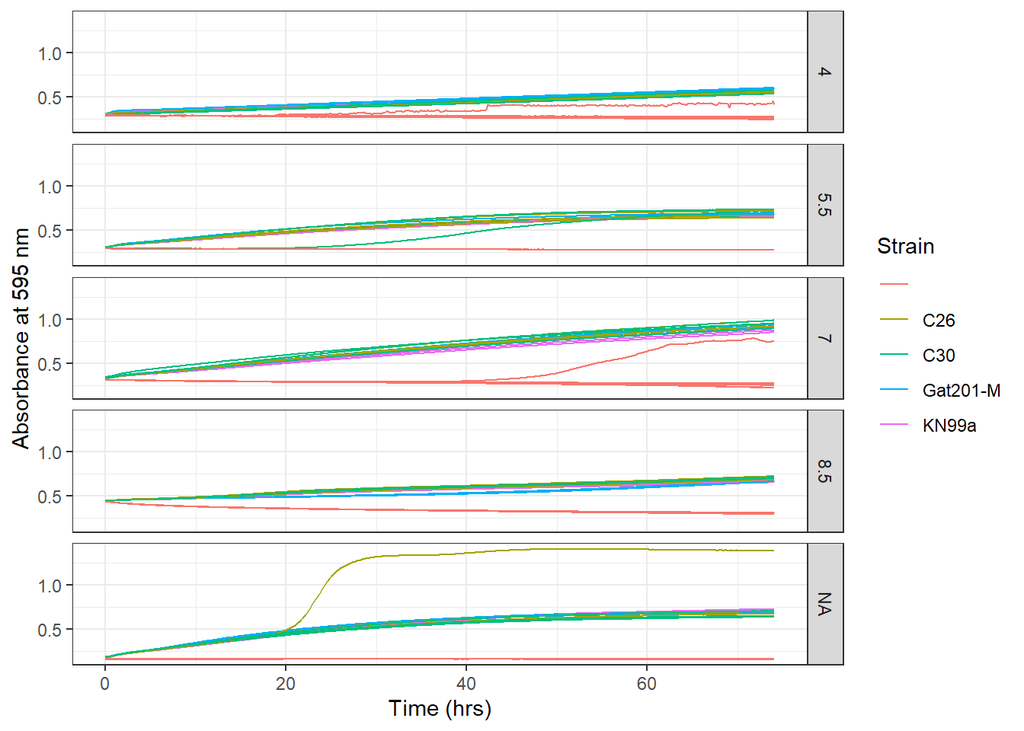

```r
ggplot(data=annotated, aes(x=Time, y=OD595, color=Strain, group = Well)) +
       geom_line() +
       theme_bw()+
       facet_grid(pH ~ .) +
       labs(x="Time (hrs)", y="Absorbance at 595 nm")
```

#Plot all ODs by Medium, unnormalised

## This allows you to check the data by pH

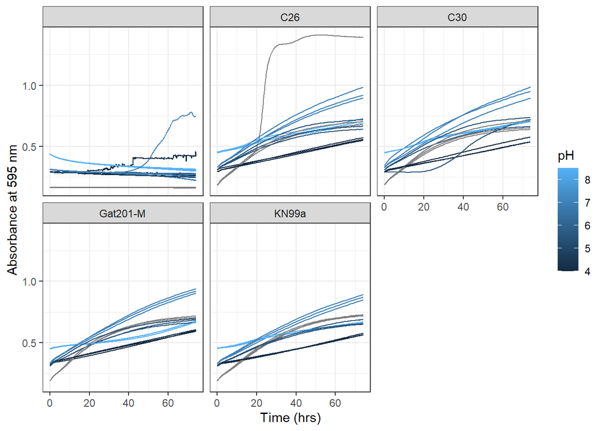

```r
ggplot(data=annotated, aes(x=Time, y=OD595, color=pH, group=Well)) +
       geom_line() +
       theme_bw()+
       facet_wrap(Strain ~ .) +
       labs(x="Time (hrs)", y="Absorbance at 595 nm")
```

# Which wells grow to higher OD?

## This helps you to pinpoint any outliers or odd wells with a much higher OD.

```r
annotated %>%
  group_by(Well) %>%
  summarise(maxOD=max(OD595)) %>%
  arrange(desc(maxOD))
```

```
## # A tibble: 96 × 2
##    Well  maxOD
##    <chr> <dbl>
##  1 F2    1.41
##  2 G9    0.986
##  3 G8    0.984
##  4 F9    0.951
##  5 D9    0.940
##  6 C9    0.920
##  7 F8    0.918
##  8 B9    0.904
##  9 E9    0.896
## 10 E8    0.896
## # ℹ 86 more rows
```

# How stable are ODs of blank wells, to use for normalisation?

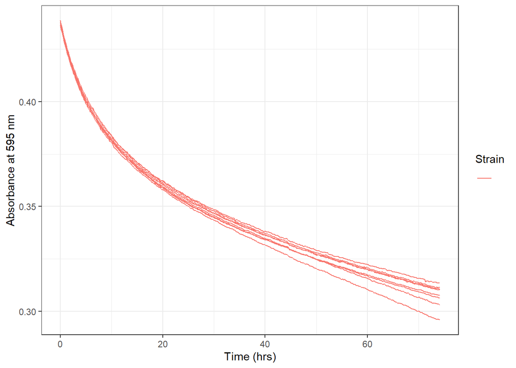

```r
ggplot(data=filter(annotated,Strain=="", pH=="8.5"),
       aes(x=Time, y=OD595, color=Strain, group = Well)) +
       geom_line() +
       theme_bw()+
       labs(x="Time (hrs)", y="Absorbance at 595 nm")
```

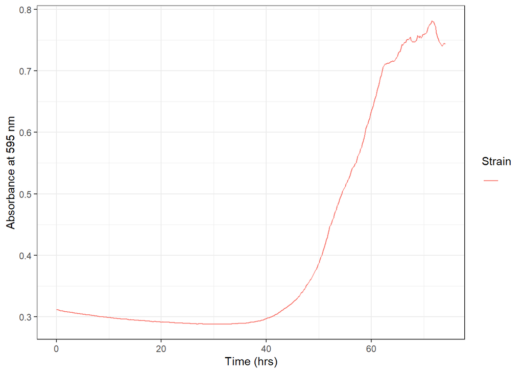

```r
ggplot(data=filter(annotated,Well=="H9"),
       aes(x=Time, y=OD595, color=Strain, group = Well)) +
       geom_line() +
       theme_bw()+
       labs(x="Time (hrs)", y="Absorbance at 595 nm")
```

Remove well H1 from the analysis. Remove well F12 from the analysis. Remove well H9 from the analysis.

# Calculate median OD for blank wells to use to normalise data.

```r
blank_OD_summary <- annotated %>%
  filter(Strain=="") %>%
  filter(Well!= "H1") %>%
  filter(Well!= "F12") %>%
  filter(Well!= "H9") %>%
  group_by(pH) %>%
  summarise(OD_median=median(OD595),
            OD_mean=mean(OD595),
            OD_max=max(OD595),
            OD_min=min(OD595))
print(blank_OD_summary)
```

```
## # A tibble: 5 × 5
##      pH OD_median OD_mean OD_max OD_min
##   <dbl>     <dbl>   <dbl>  <dbl>  <dbl>
## 1   4       0.280   0.276  0.298  0.245
## 2   5.5     0.281   0.281  0.295  0.274
## 3   7       0.279   0.278  0.314  0.220
## 4   8.5     0.338   0.345  0.439  0.296
## 5  NA       0.162   0.162  0.165  0.156
```

# Subtract blank OD to make corrected OD and Plot OD_corrected v Time (hrs)

## Normalize data

```r
normalisedOD <- annotated %>%
  left_join(blank_OD_summary, by="pH") %>%
  mutate(OD_corrected = OD595 - OD_median)

#view(normalisedOD)
```

#Plot all OD corrected (or normalized)

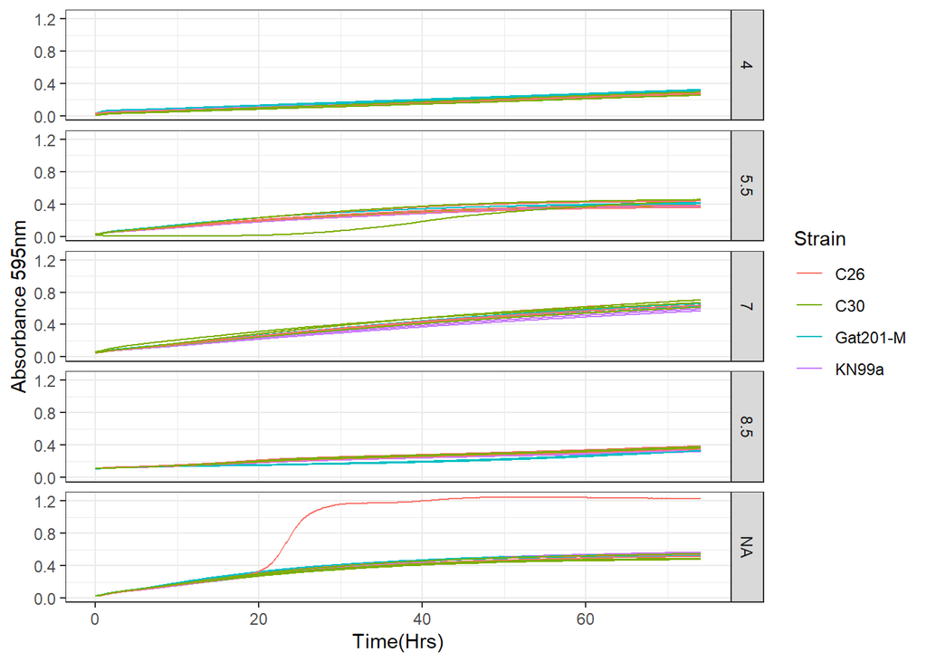

```r
ggplot(data=filter(normalisedOD,Strain !=""),  aes(x=Time, y=OD_corrected, color=Strain, group = Well)) +
       geom_line() +
       facet_grid(pH ~ .) +
       theme_bw()+
       labs(x = "Time(Hrs)") +
       labs(y = "Absorbance 595nm")
```

# Plot for All strains

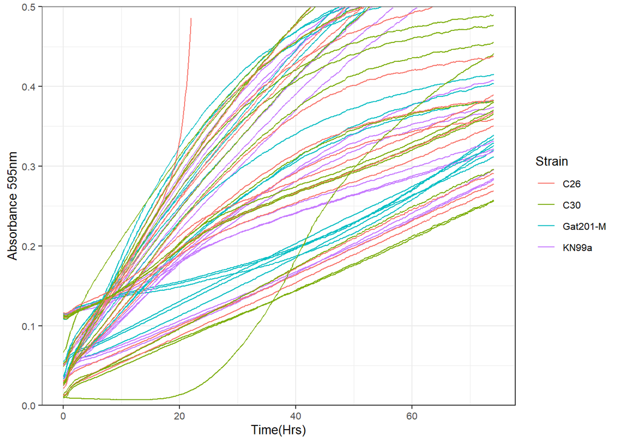

```r
ggplot(data=normalisedOD %>%
         filter(Strain != ""),
       aes(Time, OD_corrected, colour = Strain, group = Well)) +
       geom_line() +
       geom_hline(aes(yintercept=0.5), linetype="dotted", colour="black") +

       theme_bw() +
        scale_y_continuous(limits=c(0,0.5),expand=c(0,0)) +
        labs(x = "Time(Hrs)") +
        labs(y = "Absorbance 595nm") +
      theme(text = element_text(size = 10))
```

```r
strain <- filter(normalisedOD, Strain == "KN99a" )

strain2 <-  filter(normalisedOD, Strain == "Gat201-M" )

strain_all <- bind_rows(strain, strain2)

summary(strain_all)
```

```
##       Time            Temp           Well               OD595
##  Min.   : 0.00   Min.   :36.50   Length:12960       Min.   :0.1874
##  1st Qu.:18.52   1st Qu.:37.10   Class :character   1st Qu.:0.4583
##  Median :37.05   Median :37.10   Mode  :character   Median :0.5479
##  Mean   :37.05   Mean   :37.12                      Mean   :0.5496
##  3rd Qu.:55.57   3rd Qu.:37.20                      3rd Qu.:0.6424
##  Max.   :74.10   Max.   :37.40                      Max.   :0.9399
##
##     Strain              Biorep        pH          OD_median
##  Length:12960       Min.   :1   Min.   :4.000   Min.   :0.1623
##  Class :character   1st Qu.:1   1st Qu.:5.125   1st Qu.:0.2792
##  Mode  :character   Median :2   Median :6.250   Median :0.2796
##                     Mean   :2   Mean   :6.250   Mean   :0.2681
##                     3rd Qu.:3   3rd Qu.:7.375   3rd Qu.:0.2808
##                     Max.   :3   Max.   :8.500   Max.   :0.3384
##                                 NA's   :2592
##     OD_mean           OD_max           OD_min        OD_corrected
##  Min.   :0.1621   Min.   :0.1646   Min.   :0.1564   Min.   :0.0251
##  1st Qu.:0.2759   1st Qu.:0.2951   1st Qu.:0.2195   1st Qu.:0.1630
##  Median :0.2777   Median :0.2978   Median :0.2448   Median :0.2609
##  Mean   :0.2684   Mean   :0.3020   Mean   :0.2381   Mean   :0.2816
##  3rd Qu.:0.2810   3rd Qu.:0.3137   3rd Qu.:0.2740   3rd Qu.:0.3780
##  Max.   :0.3454   Max.   :0.4387   Max.   :0.2959   Max.   :0.6607
##
```

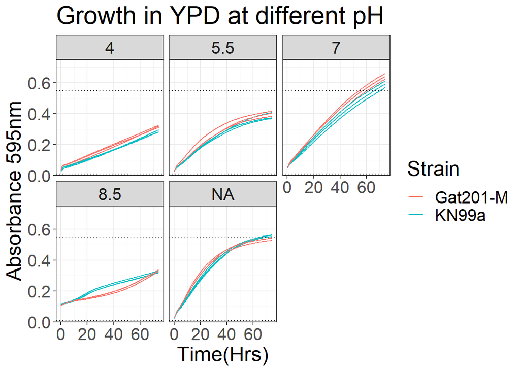

```r
ggplot(data=strain_all ,
       aes(Time, OD_corrected, colour = Strain, group = Well)) +
       geom_line() +
       geom_hline(aes(yintercept=0.55), linetype="dotted", colour="black") +
   geom_hline(aes(yintercept=0.01), linetype="dotted", colour="black") +
      facet_wrap(pH ~ .)+
       theme_bw() +
        scale_y_continuous(limits=c(0,0.75),expand=c(0,0)) +

        labs(x = "Time(Hrs)") +
        labs(y = "Absorbance 595nm") +
        labs(title = "Growth in YPD at different pH")+
      theme(text = element_text(size = 20), line = element_line(brewer.pal(2, "Set1")))
```

# Plot for individual strains

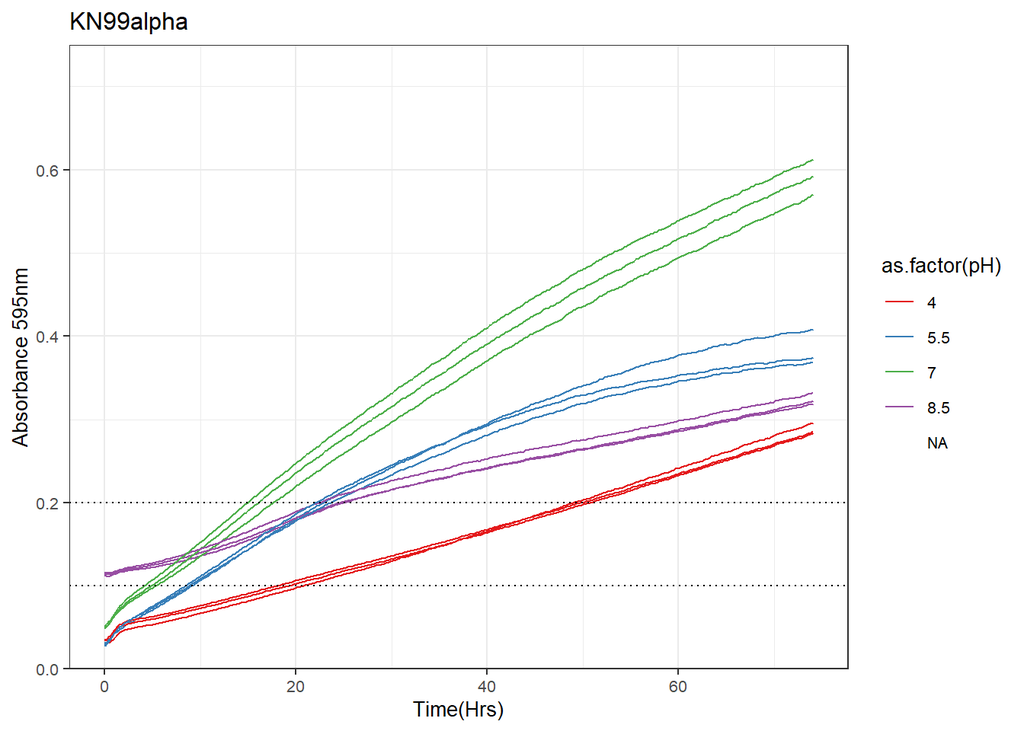

```r
ggplot(data=normalisedOD %>%
         filter(Strain == "KN99a"),
         aes(Time, OD_corrected, group = Well, colour = as.factor (pH))) +
         geom_line() +
         geom_hline(aes(yintercept=0.1), linetype="dotted", colour="black") +
          geom_hline(aes(yintercept=0.2), linetype="dotted", colour="black") +
         theme_bw() +
         scale_y_continuous(limits=c(0,0.75),expand=c(0,0)) +
         labs(x = "Time(Hrs)") +
         labs(y = "Absorbance 595nm") +
         labs(title = "KN99alpha") +
         theme(text = element_text(size = 10))+
         scale_color_brewer(palette="Set1")
```

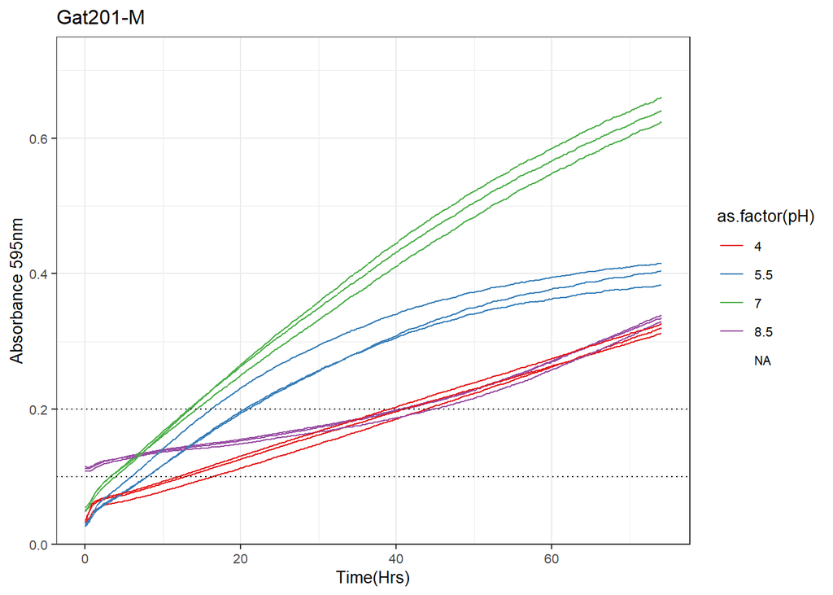

```r
ggplot(data=normalisedOD %>%
         filter(Strain == "Gat201-M"),
         aes(Time, OD_corrected, group = Well, colour = as.factor (pH))) +
         geom_line() +
         geom_hline(aes(yintercept=0.1), linetype="dotted", colour="black") +
          geom_hline(aes(yintercept=0.2), linetype="dotted", colour="black") +
         theme_bw() +
         scale_y_continuous(limits=c(0,0.75),expand=c(0,0)) +
         labs(x = "Time(Hrs)") +
         labs(y = "Absorbance 595nm") +
         labs(title = "Gat201-M") +
         theme(text = element_text(size = 10))+
         scale_color_brewer(palette="Set1")
```

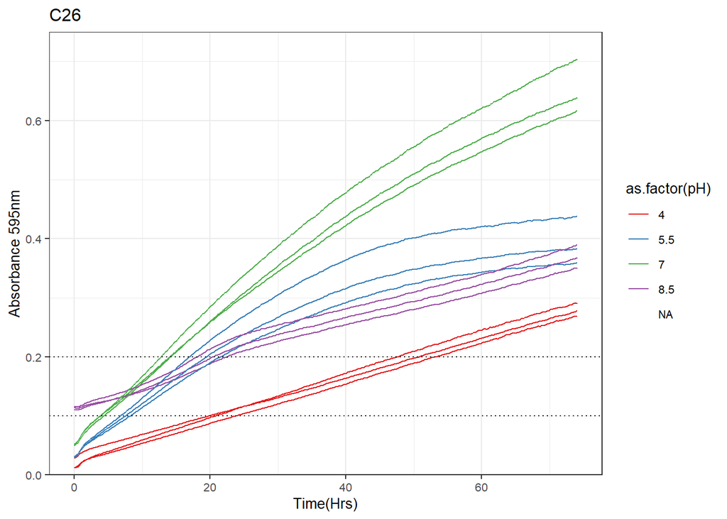

```r
ggplot(data=normalisedOD %>%
         filter(Strain == "C26"),
         aes(Time, OD_corrected, group = Well, colour = as.factor (pH))) +
         geom_line() +
         geom_hline(aes(yintercept=0.1), linetype="dotted", colour="black") +
          geom_hline(aes(yintercept=0.2), linetype="dotted", colour="black") +
         theme_bw() +
         scale_y_continuous(limits=c(0,0.75),expand=c(0,0)) +
         labs(x = "Time(Hrs)") +
         labs(y = "Absorbance 595nm") +
         labs(title = "C26") +
         theme(text = element_text(size = 10))+
         scale_color_brewer(palette="Set1")
```

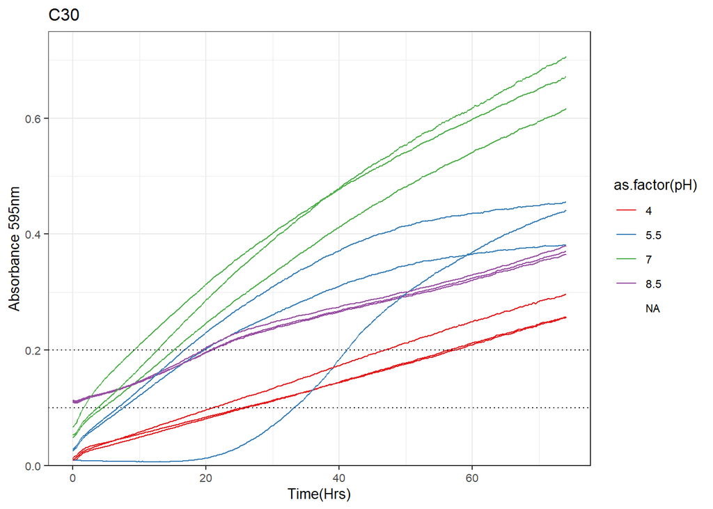

```r
ggplot(data=normalisedOD %>%
         filter(Strain == "C30"),
         aes(Time, OD_corrected, group = Well, colour = as.factor (pH))) +
         geom_line() +
         geom_hline(aes(yintercept=0.1), linetype="dotted", colour="black") +
          geom_hline(aes(yintercept=0.2), linetype="dotted", colour="black") +
         theme_bw() +
         scale_y_continuous(limits=c(0,0.75),expand=c(0,0)) +
         labs(x = "Time(Hrs)") +
         labs(y = "Absorbance 595nm") +
         labs(title = "C30") +
         theme(text = element_text(size = 10))+
         scale_color_brewer(palette="Set1")
```